# Results and visualisation

Author

Emma Belaud

**Purpose of this document**

This is the **final step** of the SEM pipeline, following:

- `1_database_edition.qmd` — assembles the SEM database
- `2_SEM_diagnostic.qmd` — selects window duration, transformation, and valid windows
- `3_SEM_modelisation.qmd` — fits all models and writes result databases

**No modelling is performed here.** Every number in every figure comes directly from pre-computed CSV files. Re-running this script is fast and safe — it never touches a model.

| Input file | Contents |
| --- | --- |
| `H1_adjusted_values.csv` | Per-observation null-model residuals with date, land-use label, season |
| `H1_model_summary.csv` | β, SE, t, p, Hedge’s g, R² from the two-step H1 model |
| `DAG_coefficients.csv` | Path coefficients from the full-dataset piecewise SEM |
| `DAG_model_fit.csv` | Fisher’s C, AIC for the full-dataset piecewise SEM |
| `SEM_results_database.csv` | Rolling-window path coefficients for all taxa |
| `indirect_effects.csv` | Rolling-window indirect effect products for all taxa |

# 1 Setup

# 2 H1 — Direct effect of land-use type on faunal activity

## 2.1 Two-step modelling approach

Figures in this section show **null-model residuals** — faunal activity with the spatial grouping structure removed.

$$y^* \sim 1 + (1 \mid \text{orientation} / \text{depth}) + \text{AR}(1)$$

**Step 2 — Test the land-use effect on residuals.**

$$\hat{\varepsilon}_{\text{Step 1}} \sim \text{land\_use}$$

β = mean(residuals at C) − mean(residuals at A). A positive β means faunal activity is higher in cultivated plots after removing orientation and depth effects.

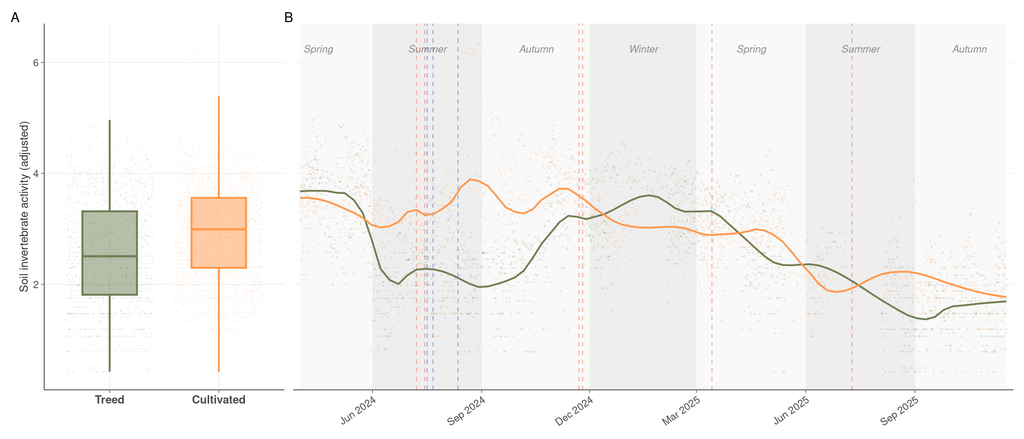

Figure 1: **Direct effect of land-use type on soil invertebrate activity.** (A) Distribution of random-effect-adjusted fauna values per land-use type. Values represent observed fauna with scanner orientation and depth effects removed, preserving the intercept so that the Y axis is in fauna units (log-transformed scale). (B) Temporal dynamics of random-effect-adjusted fauna values with LOESS smoothers (span = 0.18). Green = treed (A); orange = cultivated (C). Shaded bands = meteorological seasons. Dashed red vertical lines = agricultural interventions (wheat harvest, sorghum sowing, mowing, tillage, chickpea sowing). Dashed blue vertical lines = irrigation events.

# 3 H2 — Indirect effects through contrasting causal pathways

> **Land-use effects are mediated through contrasting causal pathways — agricultural management drives faunal activity primarily through altered microclimate, whereas treed habitats sustain faunal activity more consistently through root resource supply.**

## 3.1 Pathway algebra

The SEM estimates one standardised β per path per rolling window. An **indirect effect** is the product of all β values along a causal route. Because all continuous variables are z-scored within each window, these products are dimensionless and directly comparable across windows and pathways.

| Path | Expression |
| --- | --- |
| Direct | $\beta_9$ |
| lu → mc₁ → fauna | $\beta_1 \times \beta_6$ |
| lu → mc₂ → fauna | $\beta_2 \times \beta_7$ |
| lu → root → fauna | $\beta_5 \times \beta_8$ |
| lu → mc₁ → root → fauna | $\beta_1 \times \beta_3 \times \beta_8$ |
| lu → mc₂ → root → fauna | $\beta_2 \times \beta_4 \times \beta_8$ |
| **Total indirect** | sum of the five routes above |
| **Total effect** | direct + total indirect |

**Sign convention:** A = 0, C = 1. A negative β-product means the effect through that pathway is stronger in the treed system.

## 3.2 Table 1 — Full-dataset piecewise SEM path coefficients

Table 1: Path coefficients from the full-dataset piecewise SEM (all_taxa, complete time series, all depths). All continuous variables were z-scored after the calibration-selected transformation. β = unstandardised coefficient; Std β = standardised coefficient directly comparable to rolling-window values in Figures 2–3. R²m = marginal R² (fixed effects only); R²c = conditional R² (fixed + random effects). Fisher’s C tests global model fit: p > 0.05 indicates that the conditional independence claims implied by the DAG are consistent with the data.

| Equation | Predictor | β | Std β | SE | t | p | sig | R²m | R²c |  |  |
| --- | --- | --- | --- | --- | --- | --- | --- | --- | --- | --- | --- |
| microclimate_1 ~ land_use | land_use | 0.141 | 0.070 | 0.004 | 34.17 |  | *** | 0.000 | 0.000 |  |  |
| microclimate_2 ~ land_use | land_use | 0.186 | 0.092 | 0.012 | 16.10 |  | *** | 0.010 | 0.430 |  |  |
| root ~ microclimate_1 | microclimate_1 | -0.115 | -0.115 | 0.027 | -4.19 |  | *** | 0.030 | 0.050 |  |  |
| root ~ microclimate_2 | microclimate_2 | 0.054 | 0.054 | 0.028 | 1.91 | 0.056 | . |  |  |  |  |
| root ~ land_use | land_use | -0.085 | -0.042 | 0.029 | -2.92 | 0.004 | ** |  |  |  |  |
| fauna ~ microclimate_1 | microclimate_1 | -0.151 | -0.151 | 0.026 | -5.73 |  | *** |  |  | 0.120 | 0.250 |
| fauna ~ microclimate_2 | microclimate_2 | 0.055 | 0.055 | 0.025 | 2.15 | 0.032 | * |  |  |  |  |
| fauna ~ root | root | 0.176 | 0.176 | 0.015 | 11.93 |  | *** |  |  |  |  |
| fauna ~ land_use | land_use | 0.476 | 0.236 | 0.024 | 20.10 |  | *** |  |  |  |  |

## 3.3 Rolling-window vs. full-dataset pathway estimates

## 3.4 Figure 2

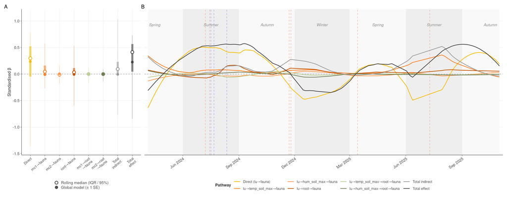

Figure 2: **Causal pathway decomposition of the land-use effect on soil invertebrate activity.** (A) Marginal distribution of standardised β-products across all rolling windows per causal pathway. Thick bar = IQR; thin bar = 95% range (after winsorising); open circle = rolling-window median; filled circle = full time-series piecewise SEM estimate ± 1 SE. (B) LOESS-smoothed (span = 0.30) time series of standardised β-products. Shaded bands = meteorological seasons. Dashed red lines = agricultural interventions; dashed blue lines = irrigation events. Sign convention: A = 0, C = 1 — negative values indicate a stronger effect in the treed system. Both panels share the same y-axis.

# 4 H3 — Land-use forcing compresses taxonomic response diversity

> **Land-use intensification compresses taxonomic response diversity by reducing the divergence among individual taxa in their sensitivity to the land-use contrast.**

## 4.1 Analysis parameters

## 4.2 Data preparation

## 4.3 Divergence computation

## 4.4 GLS regression: divergence ~ |community β|

## 4.5 Temporal dynamics per pathway

## 4.6 Figure 3

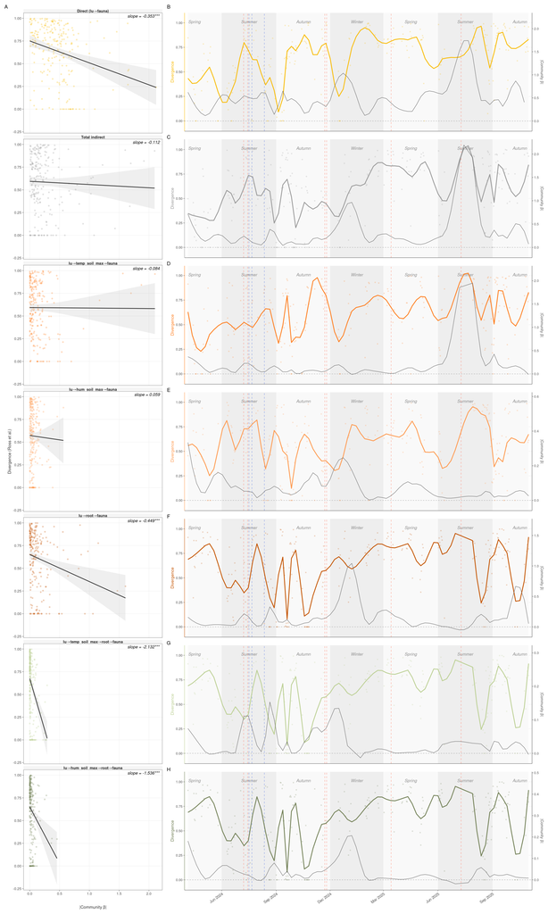

Figure 3: **Land-use forcing compresses taxonomic response diversity (Ross et al. divergence).** (A) Relationship between the Ross et al. divergence index and the absolute community-level land-use β (|community β|), per pathway. Divergence = 1 when taxon β-values span zero symmetrically; = 0 when all taxa respond in the same direction. Each point = one rolling window. Lines = OLS fits; slopes estimated by GLS with AR(1) error structure and annotated with slope and significance (*** p < 0.001). (B–H) Temporal co-variation of divergence (coloured line; left axis) and |community β| (grey line; right axis) per pathway, as LOESS smoothers (span = 0.10). Shaded bands = meteorological seasons. Dashed red lines = agricultural interventions; dashed blue lines = irrigation events.